# Project 2: Data Mining, Classification, Prediction

SDS322E

# Mining, Classification, Prediction

Timi Adio oa5782

### Introduction

One of the datasets I chose was a sample from “Penn World Table (9.1) Macroeconomic Data for Select Countries, 1950-2017” with variables: country, isocode, year, human capital, real gdp, and share of labor compensation. The other dataset I chose was “Yearly populations of countries from 1960 to 2017” with variables: country, country code 1, country code 2, year, and population. I will be analyzing the data from 2000-2017. I found both these datasets on https://vincentarelbundock.github.io/Rdatasets/datasets.html, which was on the Project 2 directions page.

```r
library(tidyverse)
# read your datasets in here, e.g., with read_csv()
countrypops <- read_csv("https://vincentarelbundock.github.io/Rdatasets/csv/gt/countrypops.csv")
pwt_sample <- read_csv("https://vincentarelbundock.github.io/Rdatasets/csv/stevedata/pwt_sample.csv")

# if your dataset needs tidying, do so here
cpops <- countrypops %>% rename(country = country_name) %>% rename(x = X1) %>%
    select(-country_code_2, -country_code_3, -x)
pwt <- pwt_sample %>% rename(x = X1) %>% select(-isocode, -pop,
    -x)
pwt <- pwt %>% left_join(cpops, by = c("year", "country")) %>%
    na.omit
# any other code here
```

### Cluster Analysis

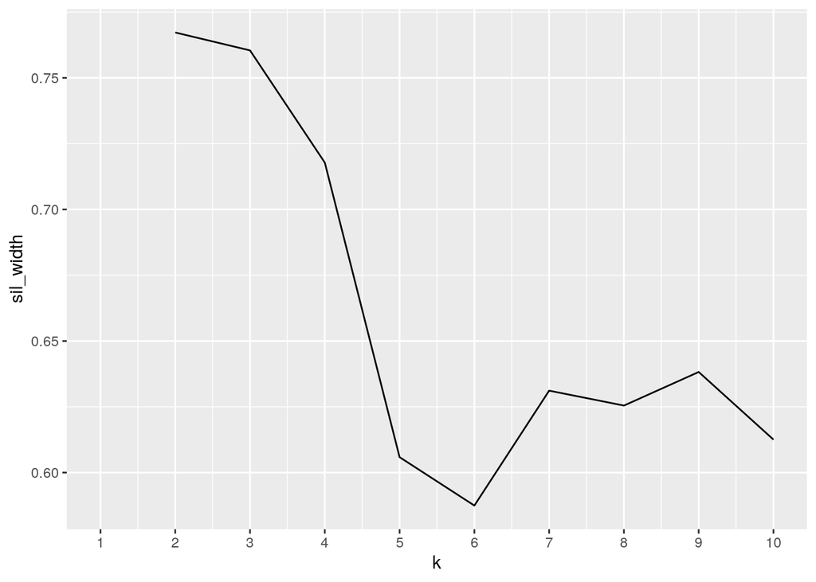

```r
library(cluster)
library(ggplot2)
# clustering code here
clust_dat <- pwt %>% select(3:6)
sil_width <- vector()  #empty vector to hold mean sil width
for (i in 2:10) {
    kms <- kmeans(clust_dat, centers = i)  #compute k-means solution for each k
    sil <- silhouette(kms$cluster, dist(clust_dat))  #get sil widths
    sil_width[i] <- mean(sil[, 3])  #take averages (higher is better)
}
ggplot() + geom_line(aes(x = 1:10, y = sil_width)) + scale_x_continuous(name = "k",
    breaks = 1:10)
```

```r
pwt_pam <- clust_dat %>% pam(k = 2)
pwt_pam
```

```
## Medoids:
##        ID       hc    rgdpna     labsh population
## [1,] 1137 3.153902  255535.1 0.5497659    8780745
## [2,]  611 2.801134 1690680.1 0.6259417   58512808
## Clustering vector:
##   [1] 1 1 1 1 1 1 1 1 1 1 1 1 1 1 1 1 1 1 1 1 1 1 1 1 1 1 1 1 1 1 1 1 1 1 1 1 1
##  [38] 1 1 1 1 1 1 1 1 1 1 1 1 1 1 1 1 1 1 1 1 1 1 1 1 1 1 1 1 1 1 1 1 1 1 1 1 1
##  [75] 1 1 1 1 1 1 1 1 1 1 1 1 1 1 1 1 1 1 1 1 1 1 1 1 1 1
##  [ reached getOption("max.print") -- omitted 1060 entries ]
## Objective function:
##   build    swap
## 9000269 8707161
##
## Available components:
##  [1] "medoids"    "id.med"     "clustering" "objective"  "isolation"
##  [6] "clusinfo"   "silinfo"    "diss"       "call"       "data"
```

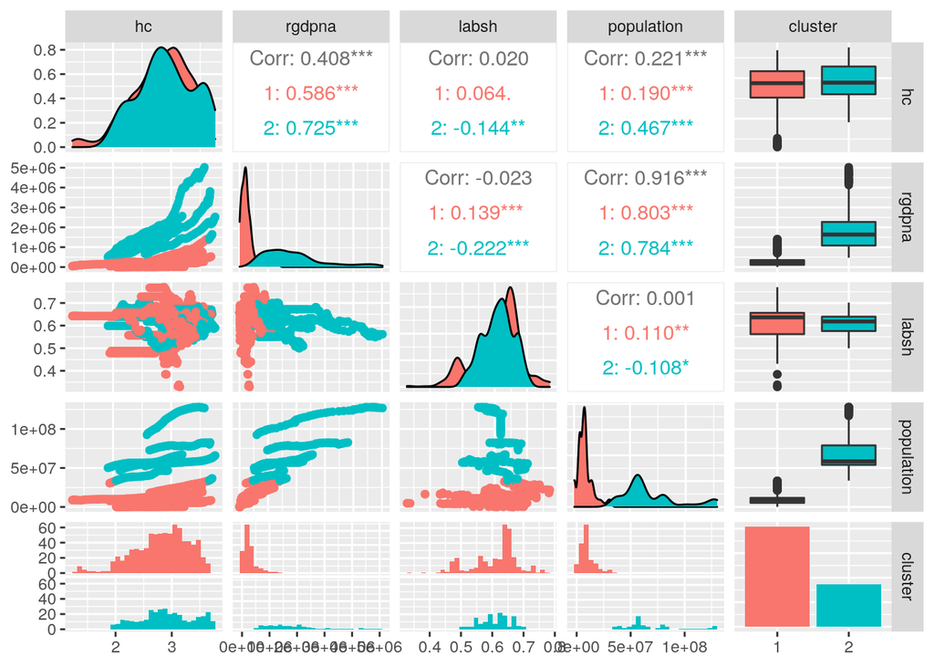

```r
library(GGally)
pwt %>% mutate(cluster = as.factor(pwt_pam$clustering)) %>% ggpairs(columns = c(3:7),
    aes(color = cluster))
```

Population showed the greatest difference between the two clusters, while human capital showed the least difference. Cluster 1 represents countries-year combos with low real gdp and population. Cluster 2 represents country-year combos with high real gdp and population. The number of clusters was based on the largest average silhouette width. Only population vs rgdpna has strong correlation (0.916), while rgdpna vs hc has fairly weak correlation (0.408). All others have very weak correlation, so weak it’s safe to assume there is no correlation between the associated variables.

### Dimensionality Reduction with PCA

```r
# PCA code here
pwt_pca <- pwt %>% select(-country, -year)
pca1 <- princomp(pwt_pca, cor = T)
summary(pca1, loadings = T)  #get PCA summary
```

```
## Importance of components:
##                           Comp.1    Comp.2    Comp.3     Comp.4
## Standard deviation     1.4484610 1.0016084 0.9144878 0.24990702
## Proportion of Variance 0.5245098 0.2508048 0.2090720 0.01561338
## Cumulative Proportion  0.5245098 0.7753147 0.9843866 1.00000000
##
## Loadings:
##            Comp.1 Comp.2 Comp.3 Comp.4
## hc          0.378  0.124  0.904  0.158
## rgdpna      0.672        -0.150 -0.724
## labsh              0.991 -0.130
## population  0.637        -0.379  0.671
```

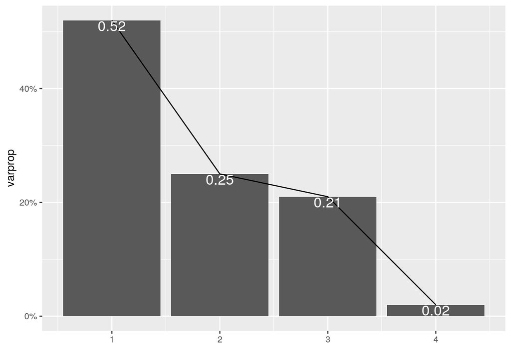

```r
eigval <- pca1$sdev^2  #square to convert SDs to eigenvalues
varprop = round(eigval/sum(eigval), 2)  #proportion of var explained by each PC

ggplot() + geom_bar(aes(y = varprop, x = 1:4), stat = "identity") +
    xlab("") + geom_path(aes(y = varprop, x = 1:4)) + geom_text(aes(x = 1:4,
    y = varprop, label = round(varprop, 2)), vjust = 1, col = "white",
    size = 5) + scale_y_continuous(breaks = seq(0, 0.6, 0.2),
    labels = scales::percent) + scale_x_continuous(breaks = 1:10)
```

```r
round(cumsum(eigval)/sum(eigval), 2)
```

```
## Comp.1 Comp.2 Comp.3 Comp.4
##   0.52   0.78   0.98   1.00
```

PC1 represents the gdp vs population axis because if a country-year combo is high in one, it tends ot be high in the other. PC2 represents the labor shortage vs human capital axis because if a country-year combo is high in one, it tends to be high in the other. PC3 represents the human capital vs population axis because if a country-year combo is high in human capital it tends to have a low population. PC4 represents the population vs gdp axis because if a country-year combo has a high population, it tends to have a low gdp. The first three principal components account for 98% of the variance.

### Linear Classifier

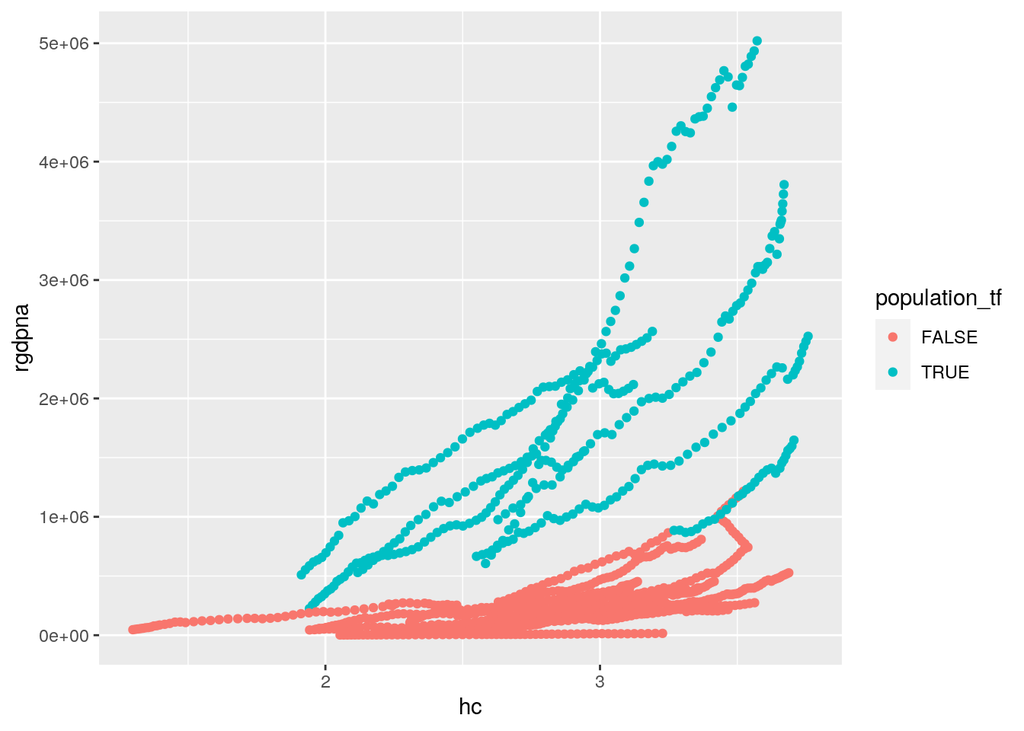

```r
pwt <- pwt %>% mutate(population_tf = population > mean(population))

ggplot(pwt, aes(hc, rgdpna, color = population_tf)) + geom_point()
```

```r
# linear classifier code here
logistic_fit <- glm(population_tf ~ hc + rgdpna, data = pwt,
    family = "binomial")
prob_reg <- predict(logistic_fit, type = "response")
class_diag(score = prob_reg, truth = pwt$population_tf, positive = "TRUE")
```

```
##            acc   sens   spec    ppv     f1     ba    auc
## Metrics 0.9793 0.9576 0.9898 0.9783 0.9678 0.9737 0.9984
```

```r
y <- pwt$population_tf
y_hat <- ifelse(prob_reg > 0.5, "TRUE", "FALSE")
table(actual = y, predicted = y_hat)
```

```
##        predicted
## actual  FALSE TRUE
##   FALSE   775    8
##   TRUE     16  361
```

```r
# cross-validation of linear classifier here
set.seed(322)
k = 10

data <- sample_frac(pwt)  #randomly order rows
folds <- rep(1:k, length.out = nrow(data))  #create folds

diags <- NULL

i = 1
for (i in 1:k) {
    # create training and test sets
    train <- data[folds != i, ]
    test <- data[folds == i, ]
    test
    truth <- test$population_tf
    # train model
    fit <- glm(population_tf ~ hc + rgdpna, data = train, family = "binomial")  ### SPECIFY THE LOGISTIC REGRESSION MODEL FIT TO THE TRAINING SET HERE

    # test model
    probs <- predict(fit, newdata = test, type = "response")  ### GET PREDICTIONS FROM THE TRAINED MODEL ON THE TEST SET HERE

    # get performance metrics for each fold
    diags <- rbind(diags, class_diag(probs, truth, positive = "TRUE"))
}

# average performance metrics across all folds
summarize_all(diags, mean)
```

```
##       acc    sens    spec    ppv      f1     ba    auc
## 1 0.97758 0.95356 0.98864 0.9751 0.96374 0.9711 0.9982
```

Based on the 0.9984 AUC, the model is performing well. There is no noticeable decrease in AUC when predicting out of sample, so this model shows no signs of overfitting. The 0.0002 difference is negligible. Looking at the confusion matrix, only 2.07% of the predictions were incorrect (false positive or false negative). This is another sign the model performed well.

### Non-Parametric Classifier

```r
library(caret)
# non-parametric classifier code here
knn_fit <- knn3(population_tf ~ hc + rgdpna, data = pwt)
# your code here
prob_knn <- predict(knn_fit, newdata = pwt)[, 2]
class_diag(score = prob_knn, truth = pwt$population_tf, positive = "TRUE")
```

```
##            acc   sens   spec   ppv     f1     ba    auc
## Metrics 0.9474 0.9204 0.9604 0.918 0.9192 0.9404 0.9896
```

```r
y_hat <- ifelse(prob_knn > 0.5, "TRUE", "FALSE")
table(actual = y, predicted = y_hat)
```

```
##        predicted
## actual  FALSE TRUE
##   FALSE   752   31
##   TRUE     30  347
```

```r
# cross-validation of np classifier here
set.seed(322)
k = 10

data <- sample_frac(pwt)  #randomly order rows
folds <- rep(1:k, length.out = nrow(data))  #create folds

diags <- NULL

i = 1
for (i in 1:k) {
    # create training and test sets
    train <- data[folds != i, ]
    test <- data[folds == i, ]
    truth <- test$population_tf

    # train model
    fit <- knn_fit <- knn3(population_tf == "TRUE" ~ hc + rgdpna,
        data = train)  ### SPECIFY THE LOGISTIC REGRESSION MODEL FIT TO THE TRAINING SET HERE

    # test model
    probs <- predict(fit, newdata = test)[, 2]  ### GET PREDICTIONS FROM THE TRAINED MODEL ON THE TEST SET HERE

    # get performance metrics for each fold
    diags <- rbind(diags, class_diag(probs, truth, positive = "TRUE"))
}

# average performance metrics across all folds
summarize_all(diags, mean)
```

```
##       acc    sens    spec     ppv      f1      ba    auc
## 1 0.92071 0.87956 0.94034 0.87516 0.87622 0.90995 0.9576
```

### Regression/Numeric Prediction

```r
# regression model code here
pwt_reg <- pwt %>% select(-country, -year, -population_tf)
fit <- lm(rgdpna ~ ., data = pwt_reg)  #predict rgdpna from all other numerical variables
yhat <- predict(fit)
mean((pwt_reg$rgdpna - yhat)^2)  #MSE calculation
```

```
## [1] 106081302654
```

```r
# cross-validation of regression model here
set.seed(1234)
k = 5
data <- pwt[sample(nrow(pwt)), ]
folds <- cut(seq(1:nrow(pwt)), breaks = k, labels = F)
diags <- NULL
for (i in 1:k) {
    train <- data[folds != i, ]
    test <- data[folds == i, ]

    fit <- lm(rgdpna ~ ., data = train)

    yhat <- predict(fit, newdata = test)

    diags <- mean((test$rgdpna - yhat)^2)
}
mean(diags)  #average MSE across all folds
```

```
## [1] 38214492604
```

### Python

```r
library(reticulate)
x <- "Hello"
```

```python
# python code here
x = "World"
y = "Final"
print(r.x + " " + x)
```

```
## Hello World
```

```r
library(reticulate)
y <- "Project"
cat(c(py$y, y))
```

```
## Final Project
```

I shared R’s x object with Python by using “r.x” and shared Python’s y object in r by using “py$y” in order to combine words from each language. I formed the phrase “Hello World” (“Hello” from R) in Python and the phrase “Final Project” (“Final” from Python) in R.

### Concluding Remarks

As expected, there was high correlation between population and rgdp. because the models created were testing population based on hc and rgdpna, it was not surprising to see that the models had little trouble with accuracy given the high correlation between rgdp and population.